# Práctica 2 - Modelos Lineales 2

Hernandez Bello Diana Patricia ‘20183808’, Manrique Urbina Justo Andres ‘20091107’, Moreano Roldan Juan Pablo ‘20184093’, Parillo Apaza Jorge Hernan ‘19947810’ , Urbano Burgos Alejandrina Margarita ‘20047278’

10/26/2019

## Pregunta 1

Sea $Y$ una variable aleatoria discreta con distribución binomial negativa $\mu$ y parámetro de dispersión $\phi$, cuya función de distribución es dada por
$$f{(y)}=\frac{\Gamma{(y+\phi)}}{\Gamma{(y+1)}\Gamma{(\phi)}}{(\frac{\mu}{\mu+\phi})}^{y}{(\frac{\phi}{\mu+\phi})}^{\phi}, y=0,1,2\ldots$$

Demuestre que pertenece a la familia exponencial, para $\phi$ conocido.

La función de probabilidad de $Y$ se puede reexpresar como:
$$f{(y)}=\frac{\Gamma{(y+\phi)}}{\Gamma{(y+1)}\Gamma{(\phi)}}{(1-p)}^y+p^\phi.$$

Posteriormente, la función se puede expresar de la siguiente forma:

$$f{(y)}=\frac{\Gamma{(y+\phi)}}{\Gamma{(y+1)}\Gamma{(\phi)}} \exp(y \log(1-p) \phi \log(p).$$

En donde $p=\frac{\phi}{\mu+\phi}$ y $1-p=\frac{\mu}{\mu+\phi}$

Se observa que pertenecería a la familia exponencial en tanto $\phi$ es conocido, pues:

- $\theta=log(1-p)$
- $b(\theta)=\phi\log(p)$ o, asimismo, $b(\theta)=\phi\log(1-e^\theta)$
- $c(y,\phi)$ es igual a la función gamma.
- $\phi=1$

Demuestre que para $\phi$ conocido, la distribución de $Y$ pertenece a la familia exponencial.

Encuentre la función de varianza y la función de enlace canónica.

La función de varianza se define como:
$$V(Y)=\frac{-1}{\phi}b^{''}(\theta)$$

Resolviendo, se tiene que:
$$\frac{\partial^2}{\partial \theta^2} b(\theta)=\frac{\partial}{\partial \theta}(\frac{\phi e^\theta}{1-e^\theta})=\phi\frac{\partial}{\partial \theta}(\frac{ e^\theta}{1-e^\theta})=\phi \frac{e^\theta}{(1-e^\theta)^2}=\frac{\phi{(1-p)}}{p^2}$$

Reemplazando $p$ y $1-p$, se tiene que:

$$\frac{\frac{\phi \mu}{\mu+\phi}}{\frac{\phi^2}{(\mu+\phi)^2}}$$

Por lo tanto, la varianza es:
$$\mu + \frac{\mu^2}{\phi}.$$

La función de enlace canónica se definiría de la siguiente forma:

$$\theta=\frac{\mu}{\phi+\mu}$$

## Pregunta 2

**a)** Demuestre la matriz de información de Fisher para
$$\beta= (\beta_0,\beta_1)^T$$

En general, la matriz de información de Fisher está dada por:
$$I(\theta)= \phi\sum^n_{i=1}w_i x_i x_j$$

Esto, de forma matricial, se escribe de:

$$\phi X^TwX$$

Considerando que, para Poisson, el siguiente enlace:
$$\eta_i=\log(\mu_i)$$

y varianza $V(\mu)=\mu$.

Asimismo, se tiene que:
$$w_i=\frac{(\frac{\partial}{\partial\eta_i})^2}{V_i}$$
$$w_i=\frac{(\frac{\partial\eta_i}{\partial})^{-2}}{V_i}$$

En dónde $\frac{\partial \eta_i}{\partial \mu_i}=\frac{1}{\mu}$

Por lo tanto, reemplazando en la ecuación anterior, se tiene que:
$$w_i=\frac{(\frac{1}{\mu})^{-2}}{V_i}$$
$$w_i=\frac{\mu^2}{\mu}=\mu$$

Entonces se tiene que $w_i=\mu_i$. Por lo tanto, la matriz de información de Fisher es:
$$\phi X^TwX$$

en dónde se tiene lo siguiente:
$$\phi=1$$
$$w=diag(\mu_1,\mu_2,\ldots,\mu_n)$$

**b)** Encuentre una expresión de varianza de $\hat\beta_0 - \hat\beta_1$

Se sabe que $Var(\hat\beta)=(X^TwX)^{-1}$ para Poisson.

Para hallar $(X^TwX)$ (matriz de información de Fisher) se aplica:

$$H(\beta) =-\frac{\partial^2 l(\beta_0,\beta_1)}{\partial \beta \partial\beta'} = - \sum^n_{i=1} \frac{\partial^2 l_i(\beta_0,\beta_1)}{\partial \beta \partial\beta'}$$

Para el cálculo de $-\frac{\partial^2 l(\beta_0,\beta_1)}{\partial \beta \partial\beta'}$ se consideran las siguientes notaciones :

- $$L_i(\beta_0,\beta_1) = u^{y_1}_i(exp(-\mu_i))$$
  como contribución de la observación i
- $$L_i(\beta_0,\beta_1) = \prod^n_{i=1} L_i(\beta_0,\beta_1)$$
  como función de verosimilitud
- $$l_i(\beta_0,\beta_1) = y_i log(\mu_i) - u_i = y_i(\beta_0+\beta_1 X_i) - exp(\beta_0+\beta_1 X_i)$$
  como logaritmo de la primera expresión

Luego

$$\frac{\partial^2 l_i(\beta_0,\beta_1)}{\partial \beta^2_0} = -exp(\beta_0+\beta_1 X_1) = - \mu_i$$

$$\frac{\partial^2 l_i(\beta_0,\beta_1)}{\partial \beta^2_1} = -exp(\beta_0+\beta_1) X^2_i = - \mu_i X^2_i$$

$$\frac{\partial^2 l_i(\beta_0,\beta_1)}{\partial \beta_0 \beta_1} = -exp(\beta_0+\beta_1) X_i = - \mu_i X_i$$

De lo anterior se tiene que $H(\beta)$

$$H(\beta) = \left(\begin{array}{cc} \sum^n_{i=1} \mu_i & \sum^n_{i=1} \mu_i x_i\\ \sum^n_{i=1} \mu_i x_i & \sum^n_{i=1} \mu_i x^2_i \end{array}\right)$$

Dado que $H(\beta)=X^TwX$ y $Var(\hat\beta)=(X^TwX)^{-1}$ se tiene que :

$$Var(\hat\beta)=(H(\beta))^{-1} = \frac{1}{(\sum^n_i \mu_i)(\sum^n_i \mu_i x^2_i)-
(\sum^n_i \mu_i X_i)^2} \left(\begin{array}{cc} \sum^n_i \mu_i x^2_i& - \sum^n_i \mu_i x_i\\ - \sum^n_i \mu_i x_i & \sum^n_i \mu_i \end{array}\right)$$

Donde :
$$(\sum^n_{i=1} \mu_i)(\sum^n_{i=1} \mu_i x^2_i)-(\sum^n_{i=1} \mu_i X_i)^2 = Z$$

Se solicita :

$$Var(\hat\beta_0 - \hat\beta_1)= Var(\hat\beta_0) + Var(\hat\beta_1) - 2 Cov(\hat\beta_0,\hat\beta_1)$$

$$Z(\sum^n_{i=1} \mu_i X^2_i) + Z(\sum^n_{i=1} \mu_i) + 2 \sum^n_{i=1} \mu_i x_i$$

## Pregunta 3

```r
datos <- read.csv("~/Documents/maestria-pucp/2019-2/modelos-lineales-2/clase-7/Preg3.csv", sep=",",fileEncoding = "UTF-8")
```

```r
library(glm2)
library(faraway)
library(car)
library(spm)
library(MASS)
library(hnp)
library(ggplot2)
```

En el archivo Preg3.csv se presentan los siguientes variables medidas durante un año en una región :

- reclamos : números de reclamos en un seguro de autos para responsabilidad civil frente a terceros.
- accidentes : números de accidetes en la región
- poblacion : poblacion en la región

**a)** Estime un modelo de regresión de Poisson para explicar tasa de reclamos por habitante de la región considerando como covariables el logaritmo del número de accidentes. Presente formalmente el modelo e interprete los coeficientes estimados.

$$Yi \sim Poisson(\mu_i)$$
$$n_i = \beta_o + \beta_1 x_i$$
$$log(u_i) = n_i$$
$$u_i = t_i * \lambda_i$$

- $t_i$ = habitante de la región
- $\lambda_i$ = tasa de reclamos por habitante de la región

Donde :

- $Y_i$ = número de reclamos por habitante de la región
- $x_i$ = logaritmo del número de accidentes en la región

Análisis previo:

```r
attach(datos)
head(datos)
```

|  | reclamos | accidentes | poblacion |
| --- | --- | --- | --- |
| 1 | 1103 | 2304 | 124850 |
| 2 | 1939 | 2660 | 143500 |
| 3 | 4339 | 7381 | 470700 |
| 4 | 1491 | 3217 | 311300 |
| 5 | 3801 | 6655 | 584900 |
| 6 | 387 | 2013 | 106350 |

```r
dim(datos)
```

```
## [1] 176   3
```

Para obtener reclamos por habitante de la región

```r
y<-reclamos/poblacion
x<-log(accidentes)
```

```r
nueva_data<-as.data.frame(cbind(y,x))
head(nueva_data)
```

|  | y | x |
| --- | --- | --- |
| 1 | 0.008834602 | 7.742402 |
| 2 | 0.013512195 | 7.886081 |
| 3 | 0.009218186 | 8.906664 |
| 4 | 0.004789592 | 8.076205 |
| 5 | 0.006498547 | 8.803124 |
| 6 | 0.003638928 | 7.607381 |

**Analizando la data mediante el gráfico de dispersión**

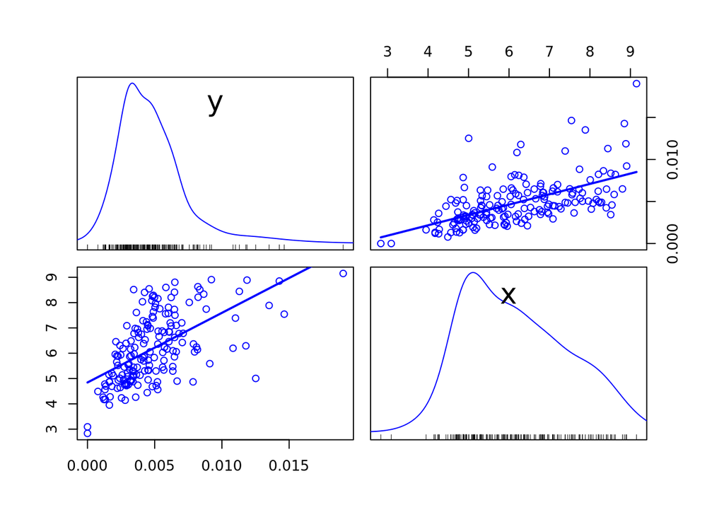

```r
scatterplotMatrix(nueva_data,smooth = FALSE)
```

Se observa que la varianza no es constante, a medida que aumenta $X$ se observa que aumenta la varianza

A continuación presentamos el primer modelo propuesto :

```r
Modelo1 <- glm(y ~ x, data=nueva_data, family=poisson(link = "log"))
```

```r
summary(Modelo1)
```

```
##
## Call:
## glm(formula = y ~ x, family = poisson(link = "log"), data = nueva_data)
##
## Deviance Residuals:
##       Min         1Q     Median         3Q        Max
## -0.065468  -0.024434  -0.005905   0.012462   0.119165
##
## Coefficients:
##             Estimate Std. Error z value Pr(>|z|)
## (Intercept)  -6.9083     5.3907  -1.282    0.200
## x             0.2468     0.7967   0.310    0.757
##
## (Dispersion parameter for poisson family taken to be 1)
##
##     Null deviance: 0.26056  on 175  degrees of freedom
## Residual deviance: 0.16506  on 174  degrees of freedom
## AIC: Inf
##
## Number of Fisher Scoring iterations: 8
```

```r
exp(coef(Modelo1))
```

```
##  (Intercept)            x
## 0.0009994421 1.2798795770
```

**Interpretación**
$$\beta_0 estimado = -6.9083$$
$$\beta_1 estimado = 0.2468$$
$$\beta_0 estimado = exp(-6.9083) \cong 0$$

Se espera que el número de reclamos por habitante de la región sea aproximadamente cero cuando el logaritmo del número de accidentes de la región es cero, es decir cuando el número de accidentes de la región es uno.

$$\beta_1 estimado = exp(0.2468) \cong 1.28$$

**b)** Realice gráficos de leverage, distancia de Cook, residuos versus valores ajustados, residuos con bandas de confianza. Comente sus resultados.

**Gráfico de Leverage y distancia de Cook**

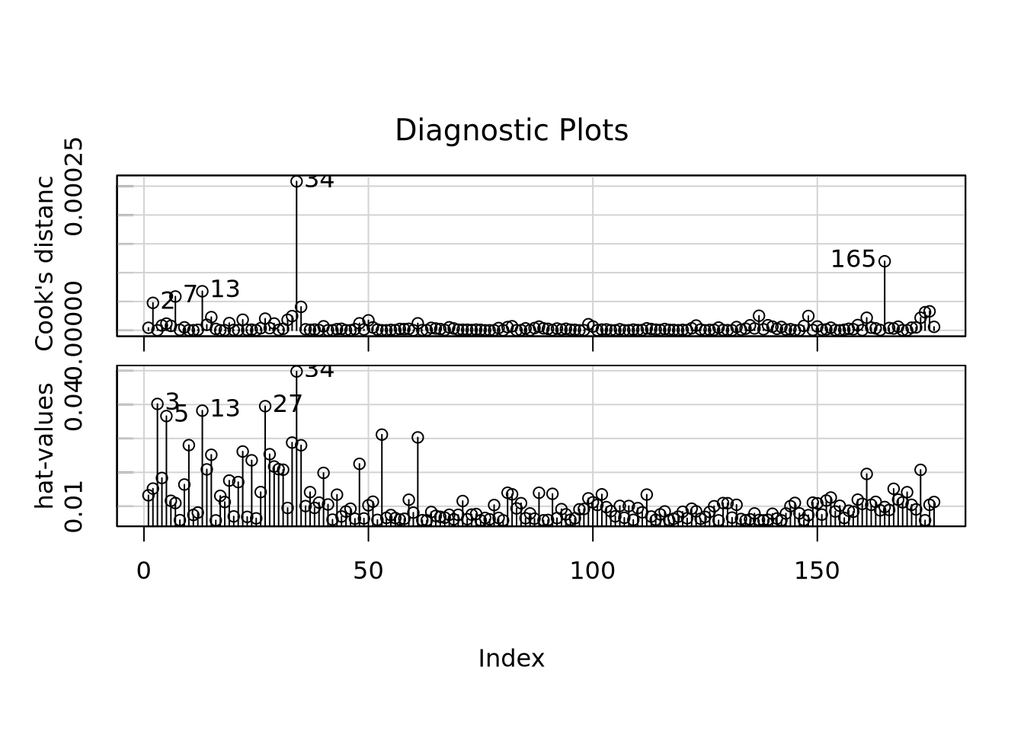

```r
influenceIndexPlot(Modelo1,vars=c ("Cook", "hat"), id=list(n=5))
```

**Comentario** En el gráfico anterior de distancias de “Cook D” nos ayuda a identificar puntos que son potencialmente influyentes debido a su ubicación en el rango de los datos.

También hay que notar el segundo gráfico donde se muestran los atípicos en las covariables x, h(hatvalues). A esto se le conoce como leverage o apalancamiento.

Se recomienda retirar los puntos con alta distancia de cook y alto leverage effect(atípico en la covariable) como por ejemplo el punto 34.

**Gráfico de residuos versus valores ajustados**

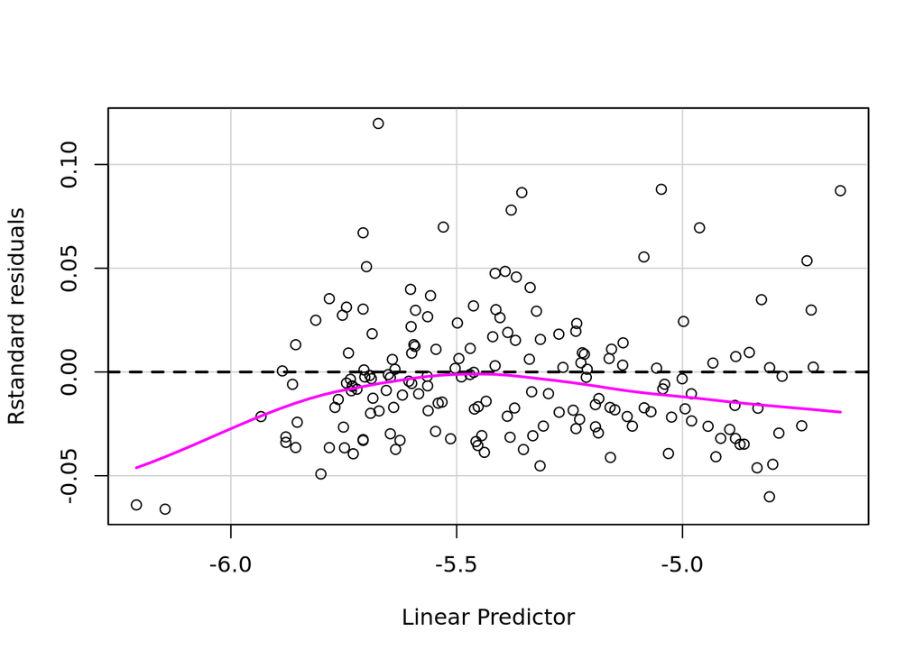

```r
residualPlot(Modelo1,type="rstandard")
```

El modelo de Poisson es heterocedástico

Función de varianza:
$$V(μ)=μ$$

No se muestra patrones, es casi casi un ruido blanco, pero parece que hubiera mayor dispersión que en un modelo Poisson.

**Gráfico de residuos con bandas de confianza**

```r
library(hnp)
hnp(Modelo1,halfnormal = FALSE)
```

```
## Poisson model
```

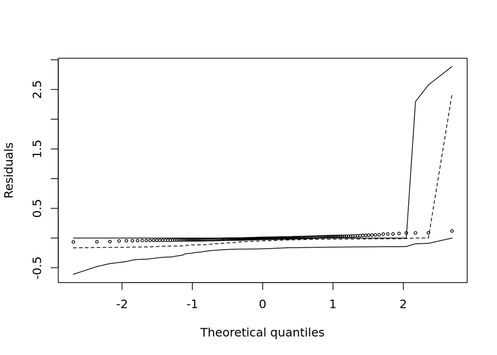

**Comentario**

Vemos que hay varios puntos que se quedan fuera de la banda, lo que indica que este modelo no ajusta bien a los datos.

Este gráfico de bandas y el anterior de residuos, nos hace pensar que necesitamos un modelo que contemple mayor varianza para que se ajuste mejor a los datos, como el modelo Binomial Negativa.

**c)** En base a sus resultados en b) de ser necesario proponga un nuevo modelo y realice un análisis de diagnóstico que incluya el estudio del efecto de posibles observaciones infuyentes. Indique cuál sería el modelo adecuado para este problema.

**Modelo 2 : Binomial Negativa**

$$Yi \sim BN(ui,\phi)$$
$$n_i = \beta_o + \beta_1 x_i$$
$$log(u_i) = n_i$$
$$E(Y_i) = u_i$$
$$Var(Y_i) = u_i + \frac{u_i^2}{\phi}$$
, tiene por propiedad más varianza que el Modelo de Poisson.

Donde :

- $Yi$ : número de reclamos por habitante de la región
- $Xi$ : logaritmo del número de accidentes en la región

Además, se retira del modelo el caso 34, por lo visto en los gráficos de leverage y distancias de Cook.

```r
Modelo2=glm.nb(y ~ x, data=nueva_data, subset=-34)
```

Coeficientes estimados

```r
summary(Modelo2)
```

```
##
## Call:
## glm.nb(formula = y ~ x, data = nueva_data, subset = -34, init.theta = 70769.2186,
##     link = log)
##
## Deviance Residuals:
##     Min       1Q   Median       3Q      Max
## -0.2567  -0.1992  -0.1643   0.2433   0.3630
##
## Coefficients:
##             Estimate Std. Error z value Pr(>|z|)
## (Intercept)  -6.8135     5.4785  -1.244    0.214
## x             0.2307     0.8169   0.282    0.778
##
## (Dispersion parameter for Negative Binomial(70769.22) family taken to be 1)
##
##     Null deviance: 8.9247  on 174  degrees of freedom
## Residual deviance: 8.8453  on 173  degrees of freedom
## AIC: 15.56
##
## Number of Fisher Scoring iterations: 1
##
##
##               Theta:  70769
##           Std. Err.:  11219953
## Warning while fitting theta: iteration limit reached
##
##  2 x log-likelihood:  -9.56
```

```r
exp(coef(Modelo2))
```

```
## (Intercept)           x
## 0.001098867 1.259423018
```

Gráfico de leverage y distancia de Cook

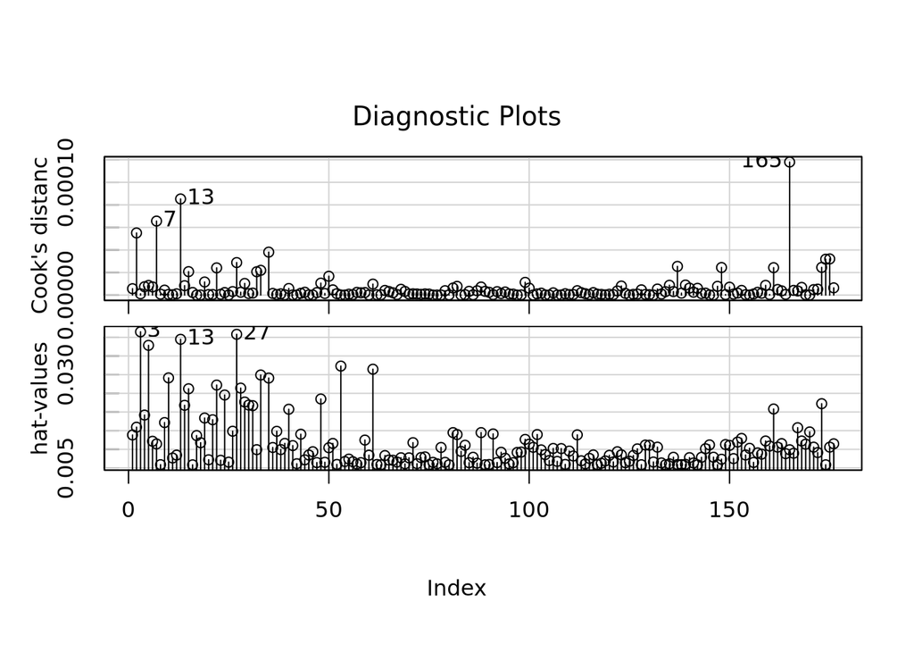

```r
influenceIndexPlot(Modelo2,vars=c ("Cook", "hat"), id=list(n=3))
```

Del gráfico anterior , se recomienda retirar los puntos con alta distancia de cook y alto leverage effect como por ejemplo el punto 13.

Gráfico de residuos versus valores ajustados

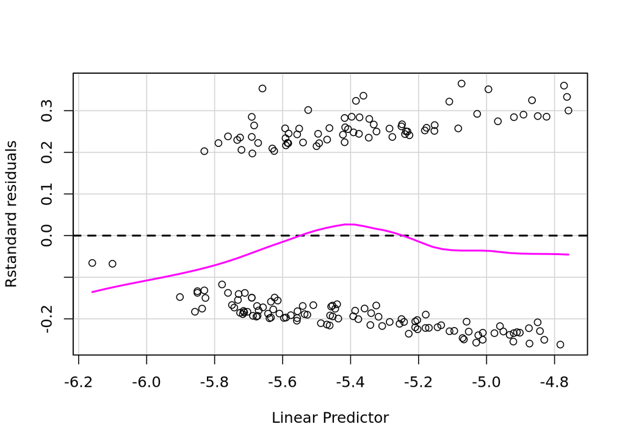

```r
residualPlot(Modelo2,type="rstandard")
```

Gráfico de residuos con bandas de confianza

```r
hnp(Modelo2,halfnormal = FALSE)
```

```
## Negative binomial model (using MASS package)
```

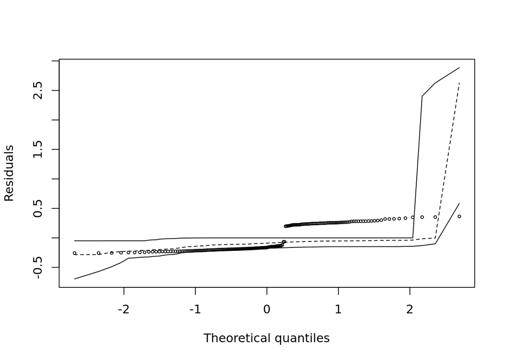

**Comentario** Vemos que los puntos están dentro de las bandas hasta un punto donde se salen de las bandas y forman una región fuera de ellas, lo que indica que este modelo tampoco ajusta bien a todos los datos.

El gráfico de bandas de este modelo y del anterior nos hace pensar que faltan considerar más covariables para encontrar un modelo que ajuste mejor.

**Modelo 3 : Binomial Negativa**

```r
Modelo3=glm.nb(y ~ x, data=nueva_data, subset=-c(34,13))
```

Coeficientes estimados

```r
summary(Modelo3)
```

```
##
## Call:
## glm.nb(formula = y ~ x, data = nueva_data, subset = -c(34, 13),
##     init.theta = 71125.50582, link = log)
##
## Deviance Residuals:
##     Min       1Q   Median       3Q      Max
## -0.2565  -0.1984  -0.1651   0.2434   0.3634
##
## Coefficients:
##             Estimate Std. Error z value Pr(>|z|)
## (Intercept)  -6.7600     5.5458  -1.219    0.223
## x             0.2214     0.8321   0.266    0.790
##
## (Dispersion parameter for Negative Binomial(71125.51) family taken to be 1)
##
##     Null deviance: 8.7910  on 173  degrees of freedom
## Residual deviance: 8.7206  on 172  degrees of freedom
## AIC: 15.423
##
## Number of Fisher Scoring iterations: 1
##
##
##               Theta:  71126
##           Std. Err.:  11404247
## Warning while fitting theta: iteration limit reached
##
##  2 x log-likelihood:  -9.423
```

```r
exp(coef(Modelo3))
```

```
## (Intercept)           x
## 0.001159269 1.247813474
```

$$\beta_0 estimado = -6.7600$$
$$\beta_1 estimado = 0.2214$$
$$\beta_0 estimado = exp(-6.7600) \cong 0$$

Se espera que el número de reclamos por habitante de la región sea aproximadamente cero cuando el logaritmo del número de accidentes de la región es cero, es decir cuando el número de accidentes de la región es uno.

$$\beta_1 estimado = exp(0.2214) \cong 1.25$$

Cuando ocurre un incremento de uno en el logaritmo del número de accidentes de la región, se espera que esto genere un incremento de 25% en el número de reclamos por habitante de la región.

**Gráfico de Leverage y distancia de Cook**

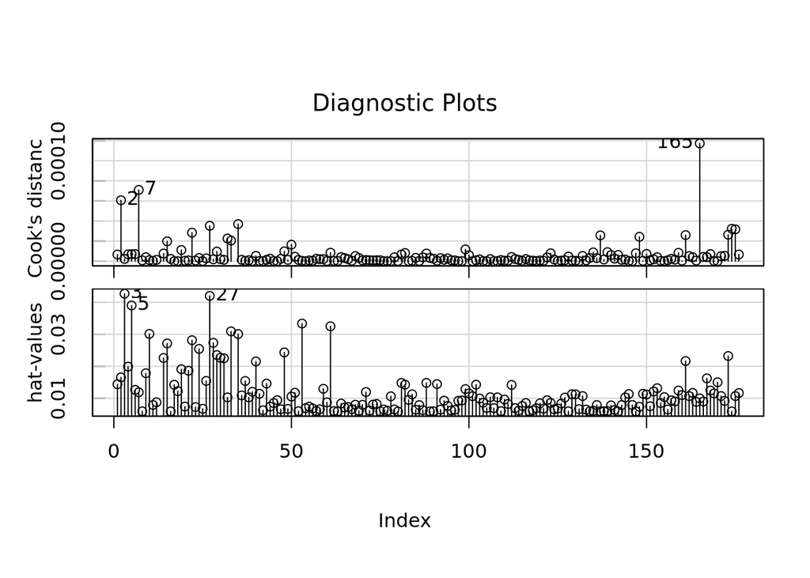

```r
influenceIndexPlot(Modelo3,vars=c ("Cook", "hat"), id=list(n=3))
```

**Comentario** Se recomienda retirar los puntos con alta distancia de cook y alto leverage effect(atípico en la covariable) , en este modelo no tenemos puntos que cumplan ambas condiciones.

**Gráfico de residuos versus valores ajustados**

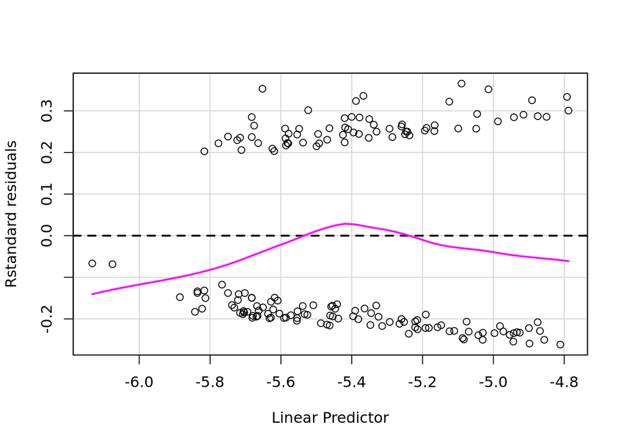

```r
residualPlot(Modelo3,type="rstandard")
```

**Gráfico de residuos con bandas de confianza**

```r
hnp(Modelo3,halfnormal = FALSE)
```

```
## Negative binomial model (using MASS package)
```

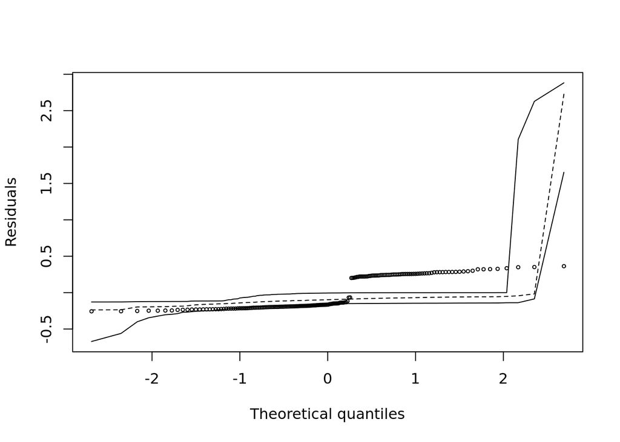

```r
AIC(Modelo1)
```

```
## [1] Inf
```

```r
AIC(Modelo2)
```

```
## [1] 15.55971
```

```r
AIC(Modelo3)
```

```
## [1] 15.42255
```

Por el criterio AIC el mejor modelo es el **Modelo 3**

Pero el gráfico de bandas de residuos con bandas de confianza nos dice que ninguno de estos 3 modelos ajusta bien a los datos, sugerimos adicionar otras covariables que ayuden a explicar mejor.

## Pregunta 4

La base de datos utilizada para el presente informe contiene las siguientes variables:

- - nsiniestros: Cantidad de siniestros ocurridos.
- - Asegurados_Total: Cantidad de asegurados en cada una de las pólizas.
  - Planilla_total: Monto mensual de salario pagado a los empleados en unidades monetarias dentro de cada póliza.
  - nivel_riesgo: Esta variable fue construida clasificando las actividades de riesgo del 1 al 5, donde 5 significa que la actividad económica que desarrolla la empresa tiene mayor exposición al riesgo de accidente o enfermedad profesional y 1 que la exposición a estos riesgos es menor.

La presente base de datos contiene 14,064 observaciones. Estas observaciones fueron recabadas por un período de 3 años.

**Objetivo**

El objetivo de este análisis es modelar el número de reclamos de una póliza de seguro de vida contratada para un grupo asegurado (que consiste en todos los empleados de una empresa), mediante las variables explicativas: número de asegurados, planilla mensual (salario mensual del grupo) y nivel de riesgo de la actividad económica de la empresa.

Los datos considerados en el análisis contemplan las Pólizas vigentes a corte dic/2017 de un producto de Seguro de Vida de una Compañía de Seguros de Perú. En cada una de estas pólizas al menos uno de los miembros del grupo asegurado ha presentado un reclamo de invalidez o los familiares de los miembros del grupo han presentado por lo menos un reclamo de fallecimiento en un periodo de tres años.

El estudio se compone de un análisis exploratorio de los datos, selección del mejor modelo, análisis de diagnóstico del mismo e interpretación de resultados.

### Análisis Exploratorio

Para realizar el análisis exploratorio inicial, realizaremos la carga de los datos en el siguiente código:

```r
library(dplyr)
library(car)
library(ggplot2)
library(car)
library(GGally)
library(stargazer)
library(hnp)
setwd("/home/justomanrique/Documents/maestria-pucp/2019-2/modelos-lineales-2/clase-7/")
datos_preg4 <- readxl::read_excel("pregunta4_diana_v2.xlsx")

datos_preg4 = datos_preg4 %>%
  mutate (  ACTIVIDAd=as.factor(ACTIVIDAd),
            nivel_riesgo=as.factor(nivel_riesgo))
```

```r
nombres = c("ACTIVIDAd","Asegurados_total","Planilla_total","nsiniestros","nivel_riesgo")
datos_preg4 = subset ( datos_preg4 , select = nombres )
datos_preg4 = na.omit ( datos_preg4 )

datos_preg4 = datos_preg4 %>%
  mutate (  ACTIVIDAd=as.factor(ACTIVIDAd),
            nivel_riesgo=as.factor(nivel_riesgo))

datos_preg4 = datos_preg4[,2:5]

summary(datos_preg4)
```

```
##  Asegurados_total   Planilla_total      nsiniestros       nivel_riesgo
##  Min.   :    1.00   Min.   :       2   Min.   : 0.00000   1:1063
##  1st Qu.:    6.00   1st Qu.:    8075   1st Qu.: 0.00000   2:1736
##  Median :   11.00   Median :   14300   Median : 0.00000   3:1183
##  Mean   :   37.26   Mean   :   76161   Mean   : 0.01465   4:5705
##  3rd Qu.:   25.00   3rd Qu.:   36496   3rd Qu.: 0.00000   5:4377
##  Max.   :13401.00   Max.   :50044818   Max.   :24.00000
```

### Selección de modelos

```r
modelo1 <- glm(nsiniestros ~ log(Asegurados_total) + log(Planilla_total) + nivel_riesgo,
data=datos_preg4, family=poisson(link = "log"))

summary(modelo1)
```

```
##
## Call:
## glm(formula = nsiniestros ~ log(Asegurados_total) + log(Planilla_total) +
##     nivel_riesgo, family = poisson(link = "log"), data = datos_preg4)
##
## Deviance Residuals:
##     Min       1Q   Median       3Q      Max
## -3.9422  -0.1022  -0.0617  -0.0429  13.1714
##
## Coefficients:
##                        Estimate Std. Error z value Pr(>|z|)
## (Intercept)           -17.78446    0.81749 -21.755  < 2e-16 ***
## log(Asegurados_total)   0.07980    0.11724   0.681  0.49608
## log(Planilla_total)     1.04650    0.09911  10.559  < 2e-16 ***
## nivel_riesgo2           0.65363    0.40554   1.612  0.10702
## nivel_riesgo3           1.42285    0.43321   3.284  0.00102 **
## nivel_riesgo4           1.30232    0.31807   4.094 4.23e-05 ***
## nivel_riesgo5           1.71826    0.32990   5.208 1.90e-07 ***
## ---
## Signif. codes:  0 '***' 0.001 '**' 0.01 '*' 0.05 '.' 0.1 ' ' 1
##
## (Dispersion parameter for poisson family taken to be 1)
##
##     Null deviance: 2267.5  on 14063  degrees of freedom
## Residual deviance: 1163.7  on 14057  degrees of freedom
## AIC: 1413.9
##
## Number of Fisher Scoring iterations: 8
```

```r
round(exp(coef(modelo1)),3)
```

```
##           (Intercept) log(Asegurados_total)   log(Planilla_total)
##                 0.000                 1.083                 2.848
##         nivel_riesgo2         nivel_riesgo3         nivel_riesgo4
##                 1.923                 4.149                 3.678
##         nivel_riesgo5
##                 5.575
```

Del modelo inicial, se puede observar que:

- En la medida que incremente el nivel de riesgo (tomando como referencia el nivel 1), se espera un incremento en la cantidad de siniestros. El efecto se hace mayor, en la medida que el nivel de riesgo incrementa (ver tabla de coeficientes).
- En la medida que incremente la cantidad de asegurados, se espera que incremente el 8% la cantidad de siniestros.
- En la medida que aumente la planilla total, se espera que se incremente en 180% la cantidad de siniestros.

### Análisis de diagnóstico

La interpretación anteriormente indicada se sostiene en la medida que los supuestos del modelo se cumplan. Para ello, se realizó el siguiente análisis de diagnóstico:

#### Residuales

Ver a continuación el diagnóstico de residuales:

```r
###Gráfico de residuos con bandas de confianza
hnp(modelo1,halfnormal = FALSE)
```

```
## Poisson model
```

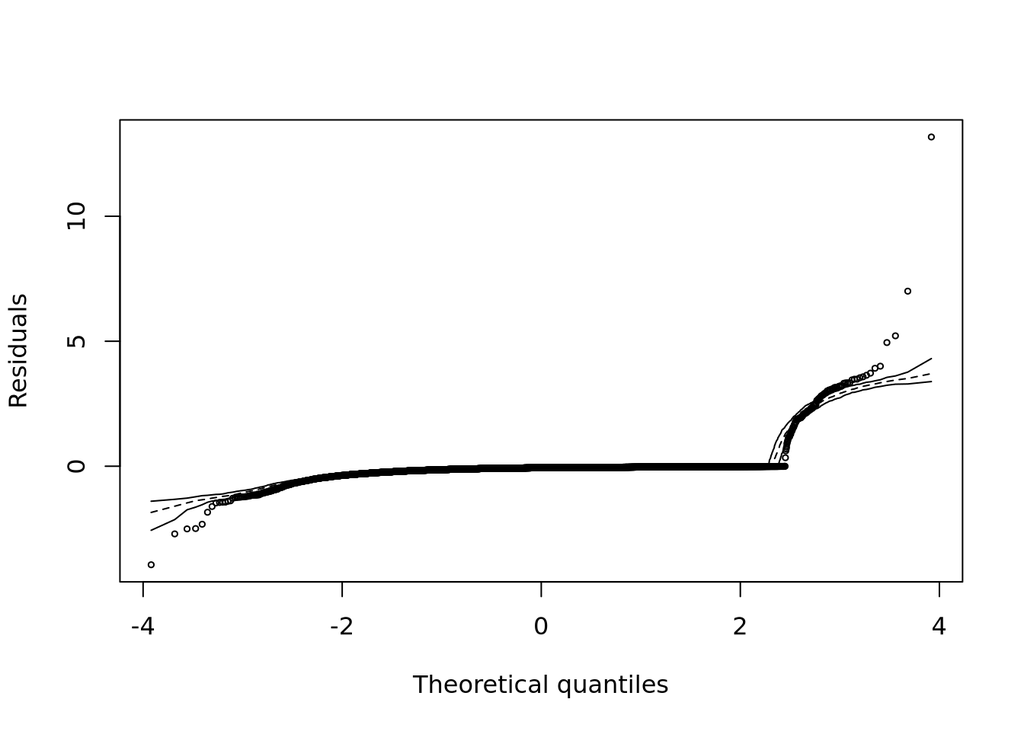

#### Visualización de puntos influyentes

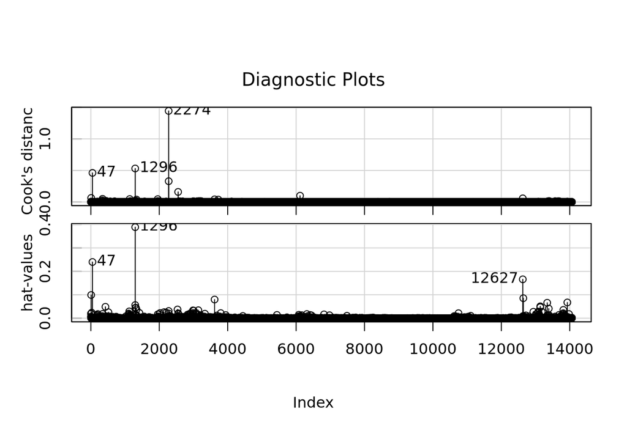

```r
###Gráfico de leverage y distancia de Cook
influenceIndexPlot(modelo1,vars=c ("Cook", "hat"), id=list(n=3))
```

### Modelo final

En base al trabajo anterior, se eliminaron los valores influyentes en común para evaluar el modelo final. Ver a continuación

```r
# Modelo 2: Poisson Regression y ~ x -c(1296,47)
modelo2 <- glm(nsiniestros ~ log(Asegurados_total) + log(Planilla_total) + nivel_riesgo, data=datos_preg4, family=poisson(link = "log"), subset = -c(1296,47))

summary(modelo2)
```

```
##
## Call:
## glm(formula = nsiniestros ~ log(Asegurados_total) + log(Planilla_total) +
##     nivel_riesgo, family = poisson(link = "log"), data = datos_preg4,
##     subset = -c(1296, 47))
##
## Deviance Residuals:
##     Min       1Q   Median       3Q      Max
## -2.9718  -0.1027  -0.0620  -0.0425  13.0147
##
## Coefficients:
##                       Estimate Std. Error z value Pr(>|z|)
## (Intercept)           -16.5470     0.9316 -17.761  < 2e-16 ***
## log(Asegurados_total)   0.2977     0.1307   2.279  0.02268 *
## log(Planilla_total)     0.8625     0.1132   7.620 2.53e-14 ***
## nivel_riesgo2           0.6561     0.4062   1.615  0.10628
## nivel_riesgo3           1.4274     0.4354   3.278  0.00105 **
## nivel_riesgo4           1.3058     0.3234   4.038 5.39e-05 ***
## nivel_riesgo5           1.7427     0.3315   5.257 1.47e-07 ***
## ---
## Signif. codes:  0 '***' 0.001 '**' 0.01 '*' 0.05 '.' 0.1 ' ' 1
##
## (Dispersion parameter for poisson family taken to be 1)
##
##     Null deviance: 1972.2  on 14061  degrees of freedom
## Residual deviance: 1142.3  on 14055  degrees of freedom
## AIC: 1387.4
##
## Number of Fisher Scoring iterations: 8
```

```r
#ha cambiado la estimacion de los parametros beta y el log(asegurados_total se ha vuelto significativo)

round(exp(coef(modelo2)),3)
```

```
##           (Intercept) log(Asegurados_total)   log(Planilla_total)
##                 0.000                 1.347                 2.369
##         nivel_riesgo2         nivel_riesgo3         nivel_riesgo4
##                 1.927                 4.168                 3.691
##         nivel_riesgo5
##                 5.713
```

Se observa que la estimación de los parámetros ha variado considerablemente para la cantidad total de asegurados (1.347 vs. 1.083), así como para la planilla (2.369 vs. 2.848). Asimismo, se observa que la cantidad total de asegurados se ha vuelto una variable significativa.

Asimismo, se han hecho los siguientes diagnósticos.

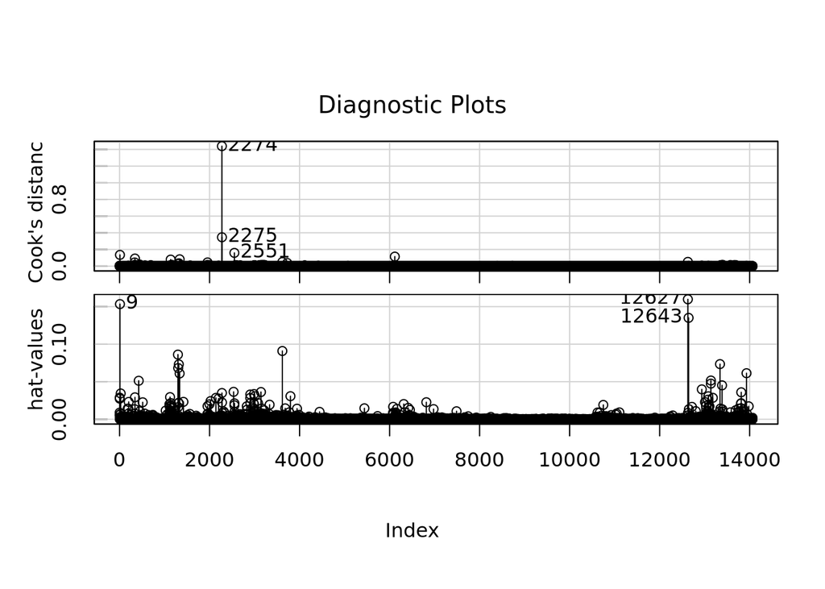

```r
##############
###Grafico de leverage y distancia de Cook

influenceIndexPlot(modelo2,vars=c ("Cook", "hat"), id=list(n=3))
```

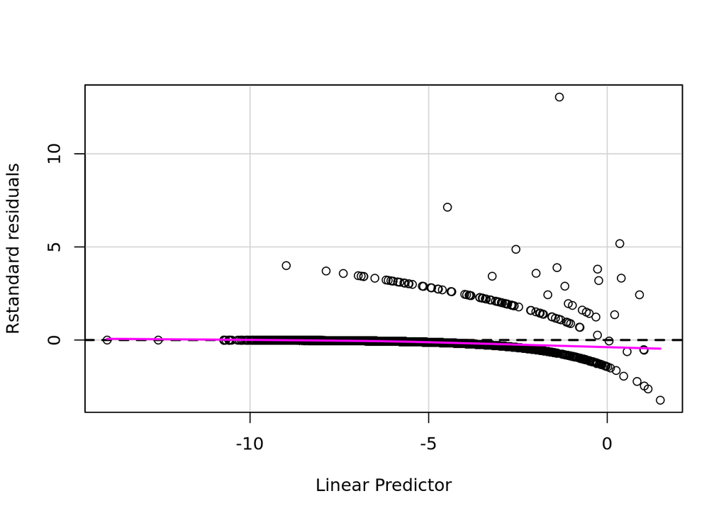

```r
###Gr?fico de residuos versus valores ajustados
residualPlot(modelo2,type="rstandard")
```

```r
###Gr?fico de residuos con bandas de confianza
hnp(modelo2,halfnormal = FALSE)
```

```
## Poisson model
```

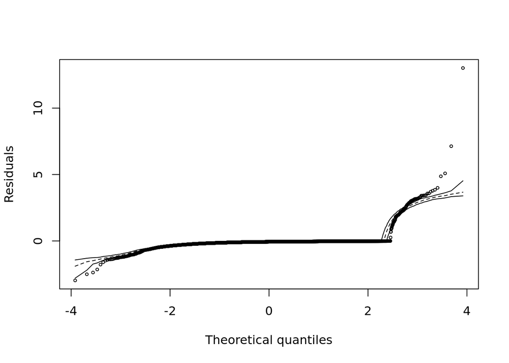

En relación a los gráficos presentados, se visualiza lo siguiente:

- Se observa que los residuales se encuentran más cerca a las bandas de confianza de los residuales, sin embargo aún persisten ciertos valores influyentes.
- Se observa que aún siguen persistiendo valores influyentes.